# Primary Outcome - Subgroups

- Show All Code
- Hide All Code
- View Source

Death from any cause or requirement of new intensive respiratory support (invasive or non-invasive ventilation) or vasopressor/inotropic support in the 28 days after randomisation.

*This script was used to undertake the subgroup analyses of the primary outcome for ASCOT.*

Author

James Totterdell

Published

July 14, 2022

## Preamble

**Load packages**

```r
library(tidyverse)
library(labelled)
library(kableExtra)
library(cmdstanr)
library(posterior)
library(bayestestR)
library(bayesplot)
library(matrixStats)
library(plotly)
library(lubridate)
library(ggdist)
library(patchwork)

theme_set(theme_classic(base_size = 10, base_family = "Palatino") +
  theme(panel.grid = element_blank(),
        strip.background = element_blank()))
bayesplot_theme_set(theme_set(theme_classic(base_size = 10, base_family = "Palatino") +
  theme(panel.grid = element_blank(),
        strip.background = element_blank())))
color_scheme_set("red")
options(digits = 4)
```

**Prepare datasets**

```r
devtools::load_all()
# Raw data
all_dat <- read_all_no_daily()
all_dat_daily <- read_all_daily()

# ACS-ITT
acs_itt_dat <- all_dat %>%
  filter_acs_itt() %>%
  transmute_model_cols_grp_aus_nz()
# ACS-ITT excluding missing values
acs_itt_nona_dat <- acs_itt_dat %>%
  filter(!is.na(PO))
```

**Models**

```r
primary_mod <- cmdstan_model("stan/binary/logistic_site_epoch.stan")
logistic_site_epoch_llik <- cmdstan_model("stan/binary/logistic_site_epoch_loglik.stan")
logistic_site_epoch_llik_int <- cmdstan_model("stan/subgroup/logistic_site_epoch_loglik_shrinkage.stan")
```

**Helper functions**

```r
make_stan_data <- function(
    dat,
    vars,
    beta_sd = c(2.5, rep(1, nXassign), 2.5, 10),
    ctr = contr.orthonorm)
{
  X <- model.matrix(
     as.formula(paste("~", paste(vars, collapse = " + "))),
    data = dat,
    contrast = list(
      AAssignment = ctr,
      CAssignment = ctr)
  )
  nXassign <- sum(grepl("Assignment", colnames(X)))

  y <- dat[["PO"]]
  N <- dim(X)[1]
  K <- dim(X)[2]
  epoch <- dat$epoch
  M_epoch <- max(dat$epoch)
  region <- dat[["ctry_num"]]
  M_region <- max(region)
  site <- dat[["site_num"]]
  M_site <- max(site)
  region_by_site <- region_by_site <- dat %>%
    dplyr::count(ctry_num, site_num) %>%
    pull(ctry_num)

  list(N = N, K = K, X = X, y = y,
       M_region = M_region, region = region,
       M_site = M_site, site = site,
       M_epoch = M_epoch, epoch = epoch,
       region_by_site = region_by_site,
       beta_sd = beta_sd)
}


fit_primary_model <- function(
    dat,
    model = primary_mod,
    vars = NULL,
    beta_sd = NULL,
    ctr = contr.treatment,
    seed = 32915,
    ...
) {
  mdat <- make_stan_data(
    dat,
    vars,
    beta_sd,
    ctr
  )
  snk <- capture.output(
    mfit <- model[["sample"]](
      data = mdat,
      seed = seed,
      refresh = 0,
      ...
  ))
  mpars <- mfit$metadata()$model_params
  keep <- mpars[!grepl("(_raw|epsilon_)", mpars)]
  mdrws <- as_draws_rvars(mfit$draws(keep))
  names(mdrws$beta) <- colnames(mdat$X)

  if(any(grepl("site", keep))) {
    site_map <- dat %>% dplyr::count(site_num, site)
    names(mdrws$gamma_site) <- site_map$site
  }
  if(any(grepl("epoch", keep))) {
    epoch_map <- dat %>% dplyr::count(epoch, epoch_lab)
    names(mdrws$gamma_epoch) <- epoch_map$epoch_lab
  }
  # Transformed samples
  Ca <- attr(mdat$X, "contrasts")$AAssignment
  Cc <- attr(mdat$X, "contrasts")$CAssignment
  # Get constrained parameters from contrast transformation
  mdrws$Acon <- Ca %**% mdrws$beta[grepl("AAssignment[0-9]$", names(mdrws$beta))]
  mdrws$Ccon <- as.vector(Cc %**% mdrws$beta[grepl("CAssignment[0-9]$", names(mdrws$beta))])
  names(mdrws$Ccon) <- rownames(Cc)
  # Get treatment effect in case of non treatment-coding
  mdrws$Atrt <- mdrws$Acon[-1] - mdrws$Acon[1]
  mdrws$Ctrt <- mdrws$Ccon[-1] - mdrws$Ccon[1]
  # Get odds ratios
  mdrws$OR <- exp(mdrws$Ctrt)
  mdrws$OR <- c(mdrws$OR, exp(mdrws$beta[!grepl("(Intercept|Assignment)", names(mdrws$beta))]))
  return(list(dat = mdat, fit = mfit, drws = mdrws))
}


make_base_subgroup_table <- function(dat, grp, format = "html") {
  tdat <- dat %>%
    dplyr::count(
      group = {{ grp }},
      `Anticoagulation intervention` = factor(
        CAssignment, labels = str_replace(intervention_labels()$CAssignment[-1], "<br>", " ")),
      PO) %>%
    complete(group, `Anticoagulation intervention`, PO, fill = list(n = 0)) %>%
    group_by(group, `Anticoagulation intervention`) %>%
    spread(PO, n, fill = 0) %>%
    ungroup() %>%
    mutate(
      Patients = `0` + `1` + `<NA>`,
      Known = `0` + `1`,
      `Primary outcome` = sprintf("%i (%.0f%%)", `1`, 100 * `1` / Known)
    ) %>%
    mutate(`Primary outcome` = str_replace(`Primary outcome`, "0 \\(NaN\\%\\)", "- (-%)")) %>%
    select(-group, -`0`, -`1`, -`<NA>`)
  kable(
    tdat,
    format = format,
    digits = 2,
    align = "lrrr",
    booktabs = TRUE) %>%
  kable_styling(
    font_size = 9,
    bootstrap_options = "striped",
    latex_options = "HOLD_position")
}

summarise_posterior <- function(dat, futval = 1.1) {
  dat %>%
    mutate(
      Median =
        sprintf("%.2f", median(Posterior)),
      `95\\% CrI` =
        sprintf("(%.2f, %.2f)", quantile(Posterior, 0.025), quantile(Posterior, 0.975)),
      `Mean (SD)` =
        sprintf("%.2f (%.2f)", mean(Posterior), sd(Posterior)),
      `Pr(OR < 1)` =
        sprintf("%.2f", Pr(Posterior < 1)),
      `Pr(OR > 1/1.1)` =
        sprintf("%.2f", Pr(Posterior > 1/futval))
    )
}


make_subgroup_summary_table <- function(dat, format = "html") {
  L <- nrow(dat)
  row_st <- seq(1, L, by = L / 3)
  row_ed <- seq(L/3, L, by = L / 3)
  kable(
    dat[, -1] %>% select(-Posterior),
    format = format,
    booktabs = TRUE,
    align = "lrrrrr",
      escape = FALSE
  ) %>%
    kable_styling(
      latex_options = "HOLD_position",
      font_size = 9
    ) %>%
    group_rows("Intermediate", row_st[1], row_ed[1]) %>%
    pack_rows("Low with aspirin", row_st[2], row_ed[2]) %>%
    pack_rows("Therapeutic", row_st[3], row_ed[3])
}


plot_subgroup_or <- function(dat, grp) {
  ggplot(ordat, aes(xdist = Posterior, y = !!grp)) +
    facet_grid( ~ Contrast, scales = "free_x") +
    stat_slabinterval(
      aes(fill =
            stat(cut_cdf_qi(
              cdf,
              .width = c(.5, .8, .95),
              labels = scales::percent_format()))),
      adjust = 1, n = 1001, .width = c(0.5, 0.8, 0.95),
      fatten_point = 1
      ) +
    scale_fill_brewer(
      palette = "Reds",
      direction = -1,
      na.translate = FALSE) +
    labs(
      x = "Odds ratio contrast",
      fill = "Interval"
    ) +
    geom_vline(xintercept = 1, linetype = 2) +
    scale_x_log10("Odds ratio (log scale)") +
    scale_colour_manual("", values = c("red", "black")) +
    guides(colour = "none") +
    theme(panel.border = element_rect(fill = NA),
          legend.position = "top")
}
```

## Subgroups

### Country

```r
make_subgroup_country_table <- function(format = "html") {
  make_base_subgroup_table(acs_itt_dat, ctry, format = format) %>%
    pack_rows("India", 1, 4) %>%
    pack_rows("Australia/New Zealand", 5, 8) %>%
    pack_rows("Nepal", 9, 12)
}
tab <- make_subgroup_country_table("latex")
save_tex_table(tab, "outcomes/primary/descriptive-acs-itt-subgroup-country-descriptive")
make_subgroup_country_table()
```

| Anticoagulation intervention | Patients | Known | Primary outcome |
| --- | --- | --- | --- |
| **India** |  |  |  |
| Low dose | 493 | 486 | 27 (6%) |
| Intermediate dose | 516 | 511 | 20 (4%) |
| Low dose with aspirin | 275 | 272 | 20 (7%) |
| Therapeutic dose | 4 | 4 | 0 (0%) |
| **Australia/New Zealand** |  |  |  |
| Low dose | 61 | 57 | 4 (7%) |
| Intermediate dose | 66 | 59 | 4 (7%) |
| Low dose with aspirin | 8 | 7 | 0 (0%) |
| Therapeutic dose | 15 | 15 | 1 (7%) |
| **Nepal** |  |  |  |
| Low dose | 56 | 53 | 4 (8%) |
| Intermediate dose | 31 | 31 | 1 (3%) |
| Low dose with aspirin | 0 | 0 | - (-%) |
| Therapeutic dose | 31 | 31 | 6 (19%) |

Primary outcome by anti-coagulation intervention by country.

```r
res <- fit_primary_model(
  acs_itt_nona_dat,
  primary_mod,
  vars = c("CAssignment", "AAssignment", "inelgc3", "agegte60", "ctry", "CAssignment:ctry"),
  beta_sd = c(2.5, rep(1, 5), 10, 2.5, 1, 1, rep(1, 6)),
  ctr = contr.treatment,
  seed = 97573,
  iter_warmup = 500,
  iter_sampling = 2500,
  chains = 8,
  parallel_chains = min(8, parallel::detectCores()),
  adapt_delta = 0.98
)

# Derive subgroup-specific effects
betaC <- res$drws$beta[grepl("CAssignment", names(res$drws$beta))]
res$drws$trtIN <- betaC[1:3]
res$drws$trtAUNZ <- betaC[1:3] + betaC[4:6]
res$drws$trtNP <- betaC[1:3] + betaC[7:9]
res$drws$logOR <- rbind(res$drws$trtIN, res$drws$trtAUNZ, res$drws$trtNP)
res$drws$OR <- exp(res$drws$logOR)
rownames(res$drws$OR) <- c("India", "Australia/New Zealand", "Nepal")
colnames(res$drws$OR) <- intervention_labels_short()$CAssignment[-(1:2)]
res$drws$compare <- sweep(res$drws$OR, 2, res$drws$OR[1, ], FUN = "/")

# Summarise subgroup effects
ordat <- expand_grid(
  Contrast = intervention_labels_short()$CAssignment[-(1:2)],
  Region = c("India", "Australia/New Zealand", "Nepal"),
) %>%
  mutate(Posterior = c(res$drws$OR)) %>%
  summarise_posterior()
# Summarise comparison of effects (reference is India)
compdat <- expand_grid(
  Contrast = intervention_labels_short()$CAssignment[-(1:2)],
  Region = c("India (ref)", "Australia/New Zealand", "Nepal")
) %>%
  mutate(Posterior = c(res$drws$compare)) %>%
  summarise_posterior() %>%
  select(-`Pr(OR > 1/1.1)`)
```

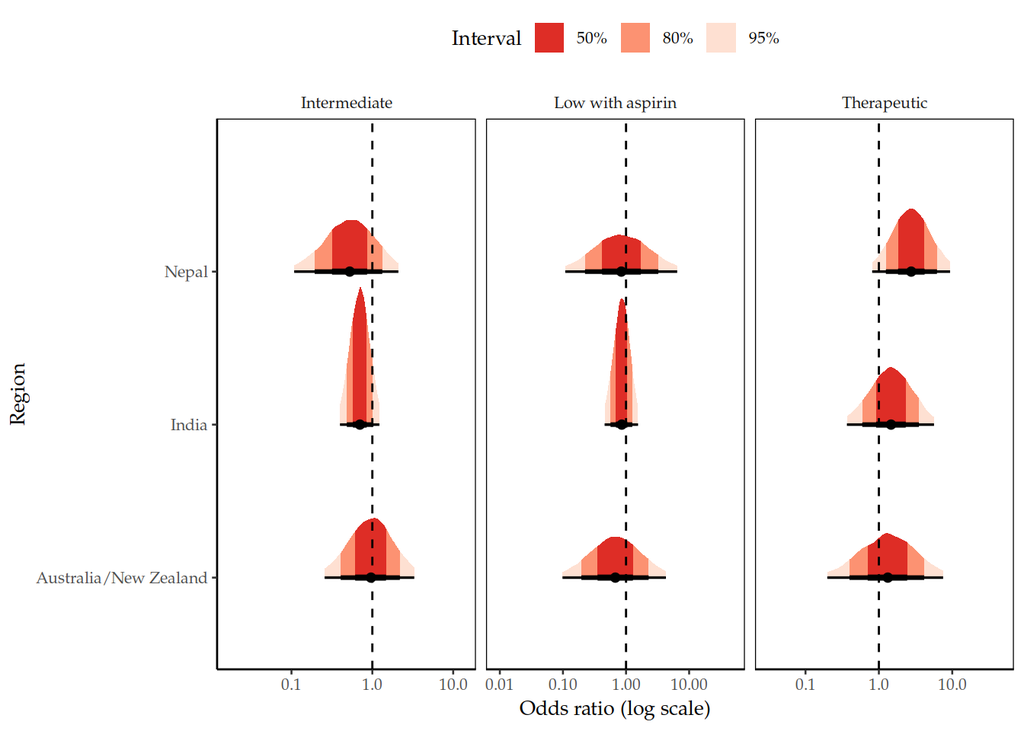

```r
p <- plot_subgroup_or(
  ordat %>%
    mutate(Region = if_else(Region == "Australia/New Zealand", "Australia\nNew Zealand", Region)),
  sym("Region"))
ggsave(
  file.path("outputs", "figures", "outcomes", "primary", "acs-itt-subgroup-country-hte.pdf"),
  p, height = 3, width = 6, device = cairo_pdf)
p
```

```r
tab <- make_subgroup_summary_table(ordat, "latex")
save_tex_table(tab, "outcomes/primary/subgroup/country-odds-ratios")
make_subgroup_summary_table(ordat)
```

| Region | Median | 95\% CrI | Mean (SD) | Pr(OR < 1) | Pr(OR > 1/1.1) |
| --- | --- | --- | --- | --- | --- |
| **Intermediate** |  |  |  |  |  |
| India | 0.70 | (0.40, 1.22) | 0.73 (0.21) | 0.89 | 0.18 |
| Australia/New Zealand | 0.96 | (0.26, 3.30) | 1.17 (0.84) | 0.52 | 0.53 |
| Nepal | 0.53 | (0.11, 2.10) | 0.68 (0.56) | 0.81 | 0.23 |
| **Low with aspirin** |  |  |  |  |  |
| India | 0.86 | (0.46, 1.55) | 0.89 (0.28) | 0.70 | 0.42 |
| Australia/New Zealand | 0.68 | (0.10, 4.29) | 1.05 (1.21) | 0.66 | 0.38 |
| Nepal | 0.84 | (0.11, 6.47) | 1.45 (1.98) | 0.56 | 0.47 |
| **Therapeutic** |  |  |  |  |  |
| India | 1.46 | (0.37, 5.64) | 1.85 (1.43) | 0.29 | 0.75 |
| Australia/New Zealand | 1.32 | (0.20, 7.51) | 1.95 (2.07) | 0.38 | 0.66 |
| Nepal | 2.76 | (0.81, 9.35) | 3.37 (2.36) | 0.05 | 0.96 |

```r
tab <- make_subgroup_summary_table(compdat, "latex")
save_tex_table(tab, "outcomes/primary/subgroup/country-odds-ratios-compare")
make_subgroup_summary_table(compdat)
```

| Region | Median | 95\% CrI | Mean (SD) | Pr(OR < 1) |
| --- | --- | --- | --- | --- |
| **Intermediate** |  |  |  |  |
| India (ref) | 1.00 | (1.00, 1.00) | 1.00 (0.00) | 0.00 |
| Australia/New Zealand | 1.37 | (0.36, 4.84) | 1.68 (1.21) | 0.32 |
| Nepal | 0.75 | (0.16, 3.01) | 0.96 (0.80) | 0.66 |
| **Low with aspirin** |  |  |  |  |
| India (ref) | 1.00 | (1.00, 1.00) | 1.00 (0.00) | 0.00 |
| Australia/New Zealand | 0.79 | (0.13, 4.70) | 1.19 (1.30) | 0.60 |
| Nepal | 0.99 | (0.14, 7.00) | 1.64 (2.10) | 0.50 |
| **Therapeutic** |  |  |  |  |
| India (ref) | 1.00 | (1.00, 1.00) | 1.00 (0.00) | 0.00 |
| Australia/New Zealand | 0.90 | (0.17, 4.56) | 1.26 (1.26) | 0.55 |
| Nepal | 1.90 | (0.45, 8.23) | 2.50 (2.10) | 0.19 |

### Age

```r
make_subgroup_age_table <- function(format = "html") {
  make_base_subgroup_table(acs_itt_dat, agegte60, format = format)  %>%
  pack_rows("Age < 60 years", 1, 4) %>%
  pack_rows("Age \u2265 60 years", 5, 8)
}
tab <- make_subgroup_age_table("latex")
save_tex_table(tab, "outcomes/primary/descriptive-acs-itt-subgroup-age-descriptive")
make_subgroup_age_table()
```

| Anticoagulation intervention | Patients | Known | Primary outcome |
| --- | --- | --- | --- |
| **Age < 60 years** |  |  |  |
| Low dose | 445 | 436 | 18 (4%) |
| Intermediate dose | 436 | 427 | 15 (4%) |
| Low dose with aspirin | 195 | 192 | 11 (6%) |
| Therapeutic dose | 26 | 26 | 3 (12%) |
| **Age ≥ 60 years** |  |  |  |
| Low dose | 165 | 160 | 17 (11%) |
| Intermediate dose | 177 | 174 | 10 (6%) |
| Low dose with aspirin | 88 | 87 | 9 (10%) |
| Therapeutic dose | 24 | 24 | 4 (17%) |

Primary outcome by anti-coagulation intervention by age group

```r
res <- fit_primary_model(
  acs_itt_nona_dat,
  primary_mod,
  vars = c("CAssignment", "AAssignment", "inelgc3", "agegte60", "ctry", "CAssignment:agegte60"),
  beta_sd = c(2.5, rep(1, 5), 10, 2.5, 1, 1, rep(1, 3)),
  ctr = contr.treatment,
  seed = 17691,
  iter_warmup = 500,
  iter_sampling = 2500,
  chains = 8,
  parallel_chains = min(8, parallel::detectCores()),
  adapt_delta = 0.98
)

# Derive subgroup-specific effects
labs <- c("Age < 60", "Age \u2265 60")
betaC <- res$drws$beta[grepl("CAssignment", names(res$drws$beta))]
res$drws$trt1 <- betaC[1:3]
res$drws$trt2 <- betaC[1:3] + betaC[4:6]
res$drws$logOR <- rbind(res$drws$trt1, res$drws$trt2)
res$drws$OR <- exp(res$drws$logOR)
rownames(res$drws$OR) <- labs
colnames(res$drws$OR) <- intervention_labels_short()$CAssignment[-(1:2)]
res$drws$compare <- sweep(res$drws$OR, 2, res$drws$OR[1, ], FUN = "/")

# Summarise subgroup effects
ordat <- expand_grid(
  Contrast = intervention_labels_short()$CAssignment[-(1:2)],
  Age = labs,
) %>%
  mutate(Posterior = c(res$drws$OR)) %>%
  summarise_posterior()
# Summarise comparison of effects (reference is India)
compdat <- expand_grid(
  Contrast = intervention_labels_short()$CAssignment[-(1:2)],
  Age = labs
) %>%
  mutate(Posterior = c(res$drws$compare)) %>%
  summarise_posterior() %>%
  select(-`Pr(OR > 1/1.1)`)
```

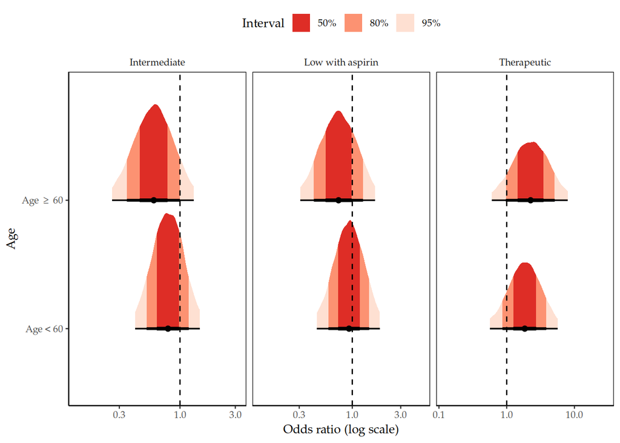

```r
p <- plot_subgroup_or(ordat, sym("Age"))
ggsave(
  file.path("outputs", "figures", "outcomes", "primary", "acs-itt-subgroup-age-hte.pdf"),
  p, height = 3, width = 6)
p
```

```r
tab <- make_subgroup_summary_table(ordat, "latex")
save_tex_table(tab, "outcomes/primary/subgroup/age-odds-ratios")
make_subgroup_summary_table(ordat)
```

| Age | Median | 95\% CrI | Mean (SD) | Pr(OR < 1) | Pr(OR > 1/1.1) |
| --- | --- | --- | --- | --- | --- |
| **Intermediate** |  |  |  |  |  |
| Age < 60 | 0.79 | (0.41, 1.48) | 0.83 (0.28) | 0.77 | 0.33 |
| Age ≥ 60 | 0.59 | (0.26, 1.32) | 0.64 (0.27) | 0.90 | 0.15 |
| **Low with aspirin** |  |  |  |  |  |
| Age < 60 | 0.93 | (0.45, 1.87) | 0.99 (0.37) | 0.58 | 0.52 |
| Age ≥ 60 | 0.73 | (0.31, 1.68) | 0.80 (0.36) | 0.76 | 0.31 |
| **Therapeutic** |  |  |  |  |  |
| Age < 60 | 1.85 | (0.57, 5.65) | 2.17 (1.35) | 0.15 | 0.89 |
| Age ≥ 60 | 2.25 | (0.60, 7.95) | 2.76 (1.98) | 0.11 | 0.92 |

```r
tab <- make_subgroup_summary_table(compdat, "latex")
save_tex_table(tab, "outcomes/primary/subgroup/age-odds-ratios-compare")
make_subgroup_summary_table(compdat)
```

| Age | Median | 95\% CrI | Mean (SD) | Pr(OR < 1) |
| --- | --- | --- | --- | --- |
| **Intermediate** |  |  |  |  |
| Age < 60 | 1.00 | (1.00, 1.00) | 1.00 (0.00) | 0.00 |
| Age ≥ 60 | 0.75 | (0.29, 1.93) | 0.85 (0.43) | 0.72 |
| **Low with aspirin** |  |  |  |  |
| Age < 60 | 1.00 | (1.00, 1.00) | 1.00 (0.00) | 0.00 |
| Age ≥ 60 | 0.79 | (0.30, 2.12) | 0.90 (0.48) | 0.68 |
| **Therapeutic** |  |  |  |  |
| Age < 60 | 1.00 | (1.00, 1.00) | 1.00 (0.00) | 0.00 |
| Age ≥ 60 | 1.23 | (0.32, 4.59) | 1.53 (1.16) | 0.38 |

### Days since symptom onset

```r
make_subgroup_dsfs_table <- function(format = "html") {
  make_base_subgroup_table(acs_itt_dat, dsfsgt7, format = format)  %>%
    pack_rows("Days since first symptoms < 8", 1, 4) %>%
    pack_rows("Days since first symptoms \u2265 8", 5, 8)
}
tab <- make_subgroup_dsfs_table("latex")
save_tex_table(tab, "outcomes/primary/descriptive-acs-itt-subgroup-dsfs-descriptive")
make_subgroup_dsfs_table()
```

| Anticoagulation intervention | Patients | Known | Primary outcome |
| --- | --- | --- | --- |
| **Days since first symptoms < 8** |  |  |  |
| Low dose | 421 | 412 | 22 (5%) |
| Intermediate dose | 432 | 426 | 20 (5%) |
| Low dose with aspirin | 206 | 203 | 15 (7%) |
| Therapeutic dose | 39 | 39 | 5 (13%) |
| **Days since first symptoms ≥ 8** |  |  |  |
| Low dose | 189 | 184 | 13 (7%) |
| Intermediate dose | 181 | 175 | 5 (3%) |
| Low dose with aspirin | 77 | 76 | 5 (7%) |
| Therapeutic dose | 11 | 11 | 2 (18%) |

Primary outcome by anti-coagulation intervention by days since first symptom group.

```r
res <- fit_primary_model(
  acs_itt_nona_dat,
  primary_mod,
  vars = c("CAssignment", "AAssignment", "inelgc3", "agegte60", "dsfsgt7", "ctry", "CAssignment:dsfsgt7"),
  beta_sd = c(2.5, rep(1, 5), 10, 2.5, 2.5, 1, 1, rep(1, 3)),
  ctr = contr.treatment,
  seed = 46732,
  iter_warmup = 500,
  iter_sampling = 2500,
  chains = 8,
  parallel_chains = min(8, parallel::detectCores()),
  adapt_delta = 0.98
)

# Derive subgroup-specific effects
labs <- c("DSFS < 8", "DSFS \u2265 8")
betaC <- res$drws$beta[grepl("CAssignment", names(res$drws$beta))]
res$drws$trt1 <- betaC[1:3]
res$drws$trt2 <- betaC[1:3] + betaC[4:6]
res$drws$logOR <- rbind(res$drws$trt1, res$drws$trt2)
res$drws$OR <- exp(res$drws$logOR)
rownames(res$drws$OR) <- labs
colnames(res$drws$OR) <- intervention_labels_short()$CAssignment[-(1:2)]
res$drws$compare <- sweep(res$drws$OR, 2, res$drws$OR[1, ], FUN = "/")

ordat <- expand_grid(
  Contrast = intervention_labels_short()$CAssignment[-(1:2)],
  `Days since first symptoms` = labs
) %>%
  mutate(Posterior = c(res$drws$OR)) %>%
  summarise_posterior()
compdat <- expand_grid(
  Contrast = intervention_labels_short()$CAssignment[-(1:2)],
  `Days since first symptoms` = labs
) %>%
  mutate(Posterior = c(res$drws$compare)) %>%
  summarise_posterior() %>%
  select(-`Pr(OR > 1/1.1)`)
```

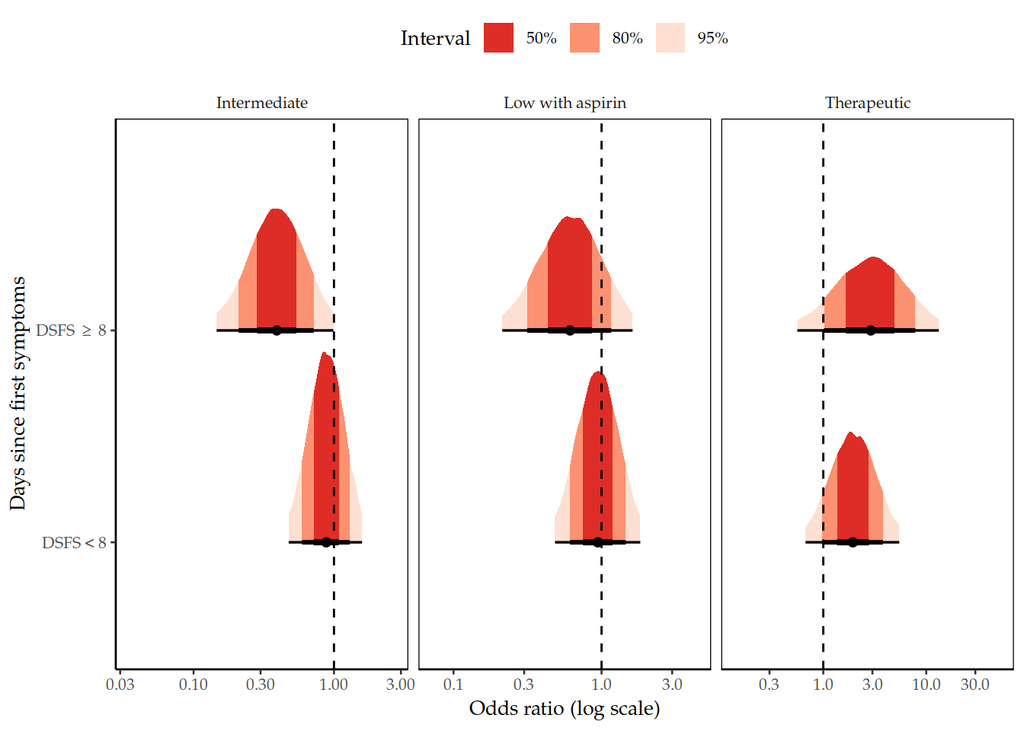

```r
p <- plot_subgroup_or(ordat, sym("Days since first symptoms"))
ggsave(file.path("outputs", "figures", "outcomes", "primary", "acs-itt-subgroup-dsfs-hte.pdf"),
       p, device = cairo_pdf,
       height = 3, width = 6)
p
```

```r
tab <- make_subgroup_summary_table(ordat, "latex")
save_tex_table(tab, "outcomes/primary/subgroup/dsfs-odds-ratios")
make_subgroup_summary_table(ordat)
```

| Days since first symptoms | Median | 95\% CrI | Mean (SD) | Pr(OR < 1) | Pr(OR > 1/1.1) |
| --- | --- | --- | --- | --- | --- |
| **Intermediate** |  |  |  |  |  |
| DSFS < 8 | 0.88 | (0.48, 1.59) | 0.92 (0.28) | 0.66 | 0.46 |
| DSFS ≥ 8 | 0.39 | (0.15, 0.99) | 0.44 (0.22) | 0.98 | 0.04 |
| **Low with aspirin** |  |  |  |  |  |
| DSFS < 8 | 0.94 | (0.48, 1.83) | 1.00 (0.35) | 0.57 | 0.54 |
| DSFS ≥ 8 | 0.61 | (0.21, 1.62) | 0.69 (0.37) | 0.84 | 0.21 |
| **Therapeutic** |  |  |  |  |  |
| DSFS < 8 | 1.94 | (0.67, 5.48) | 2.23 (1.25) | 0.11 | 0.92 |
| DSFS ≥ 8 | 2.89 | (0.56, 13.26) | 3.88 (3.50) | 0.10 | 0.92 |

```r
tab <- make_subgroup_summary_table(compdat, "latex")
save_tex_table(tab, "outcomes/primary/subgroup/dsfs-odds-ratios-compare")
make_subgroup_summary_table(compdat)
```

| Days since first symptoms | Median | 95\% CrI | Mean (SD) | Pr(OR < 1) |
| --- | --- | --- | --- | --- |
| **Intermediate** |  |  |  |  |
| DSFS < 8 | 1.00 | (1.00, 1.00) | 1.00 (0.00) | 0.00 |
| DSFS ≥ 8 | 0.44 | (0.15, 1.24) | 0.51 (0.29) | 0.94 |
| **Low with aspirin** |  |  |  |  |
| DSFS < 8 | 1.00 | (1.00, 1.00) | 1.00 (0.00) | 0.00 |
| DSFS ≥ 8 | 0.65 | (0.21, 1.87) | 0.75 (0.43) | 0.78 |
| **Therapeutic** |  |  |  |  |
| DSFS < 8 | 1.00 | (1.00, 1.00) | 1.00 (0.00) | 0.00 |
| DSFS ≥ 8 | 1.49 | (0.33, 6.30) | 1.93 (1.62) | 0.30 |

### On Room Air and Oxygen Saturation

The pre-specified subgroup analysis was for patients who were “on room air in the preceding 24 hours **or** had an oxygen saturation < 94” vs “not on room air and oxygen saturation $\geq$ 94. However, oxygen saturation was only reported for participants who were reported as on room air in the preceding 24 hours. For participants who were not on room air, their oxygen saturation was unknown. Therefore, the pre-specified subgroup is not identifiable.

```r
all_dat %>%
  filter_acs_itt() %>%
  dplyr::count(
    "On room air in preceding 24 hours" = BAS_OnRoomAir24hrs,
    "Missing peripheral oxygen" = factor(is.na(BAS_PeripheralOxygen), labels = c("No", "Yes")))
```

```
# A tibble: 3 × 3
  `On room air in preceding 24 hours` `Missing peripheral oxygen`     n
  <chr>                               <fct>                       <int>
1 No                                  Yes                           348
2 Yes                                 No                           1183
3 <NA>                                Yes                            25
```

```r
all_dat %>%
  filter_acs_itt() %>%
  dplyr::count(
    "Not on room air or oxygen 94+" =
      BAS_OnRoomAir24hrs == "No" | (BAS_OnRoomAir24hrs == "Yes" & BAS_PeripheralOxygen >= 94),
    "On room air and oxygen < 94" =
      BAS_OnRoomAir24hrs == "Yes" & BAS_PeripheralOxygen < 94)
```

```
# A tibble: 3 × 3
  `Not on room air or oxygen 94+` `On room air and oxygen < 94`     n
  <lgl>                           <lgl>                         <int>
1 FALSE                           TRUE                            275
2 TRUE                            FALSE                          1256
3 NA                              NA                               25
```

```r
make_subgroup_air_table <- function(format = "html") {
  make_base_subgroup_table(acs_itt_dat %>% filter(!is.na(airoxy)), airoxy, format = format)  %>%
    pack_rows("Not on room air or oxygen saturation \u2265 94", 1, 4) %>%
    pack_rows("On room air and oxygen saturation < 94", 5, 8)
}
tab <- make_subgroup_air_table("latex")
save_tex_table(tab, "outcomes/primary/descriptive-acs-itt-subgroup-air-descriptive")
make_subgroup_air_table()
```

| Anticoagulation intervention | Patients | Known | Primary outcome |
| --- | --- | --- | --- |
| **Not on room air or oxygen saturation ≥ 94** |  |  |  |
| Low dose | 492 | 480 | 23 (5%) |
| Intermediate dose | 507 | 499 | 17 (3%) |
| Low dose with aspirin | 222 | 218 | 11 (5%) |
| Therapeutic dose | 35 | 35 | 5 (14%) |
| **On room air and oxygen saturation < 94** |  |  |  |
| Low dose | 110 | 108 | 12 (11%) |
| Intermediate dose | 97 | 93 | 8 (9%) |
| Low dose with aspirin | 53 | 53 | 9 (17%) |
| Therapeutic dose | 15 | 15 | 2 (13%) |

```r
res <- fit_primary_model(
  acs_itt_nona_dat %>% filter(!is.na(airoxy)),
  primary_mod,
  vars = c("CAssignment", "AAssignment", "inelgc3", "agegte60", "airoxy", "ctry", "CAssignment:airoxy"),
  beta_sd = c(2.5, rep(1, 5), 10, 2.5, 2.5, 1, 1, rep(1, 3)),
  ctr = contr.treatment,
  seed = 46732,
  iter_warmup = 500,
  iter_sampling = 2500,
  chains = 8,
  parallel_chains = min(8, parallel::detectCores()),
  adapt_delta = 0.98
)

# Derive subgroup-specific effects
labs <- c("No room air or SpO2 \u2265 94", "Room air and SpO2 < 94")
betaC <- res$drws$beta[grepl("CAssignment", names(res$drws$beta))]
res$drws$trt1 <- betaC[1:3]
res$drws$trt2 <- betaC[1:3] + betaC[4:6]
res$drws$logOR <- rbind(res$drws$trt1, res$drws$trt2)
res$drws$OR <- exp(res$drws$logOR)
rownames(res$drws$OR) <- labs
colnames(res$drws$OR) <- intervention_labels_short()$CAssignment[-(1:2)]
res$drws$compare <- sweep(res$drws$OR, 2, res$drws$OR[1, ], FUN = "/")

ordat <- expand_grid(
  Contrast = intervention_labels_short()$CAssignment[-(1:2)],
  `Oxygen` = labs
) %>%
  mutate(Posterior = c(res$drws$OR)) %>%
  summarise_posterior()
compdat <- expand_grid(
  Contrast = intervention_labels_short()$CAssignment[-(1:2)],
  `Oxygen` = labs
) %>%
  mutate(Posterior = c(res$drws$compare)) %>%
  summarise_posterior() %>%
  select(-`Pr(OR > 1/1.1)`)
```

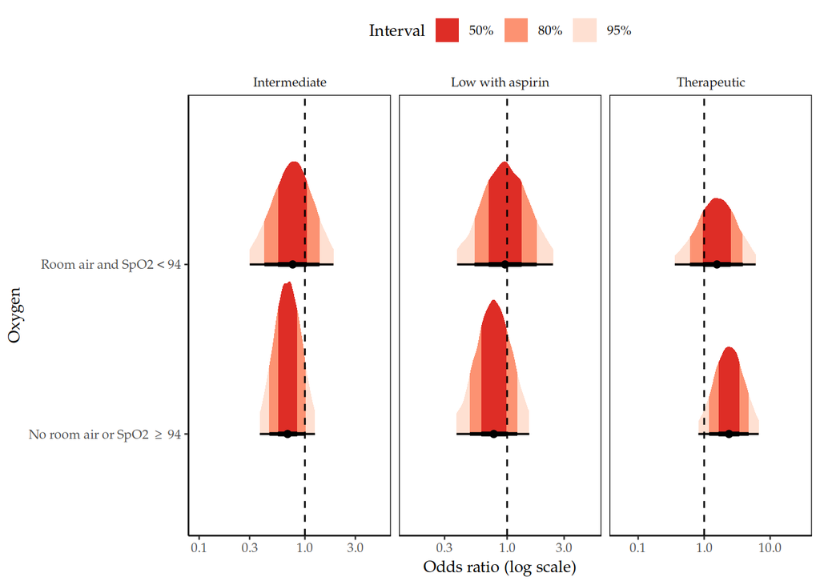

```r
p <- plot_subgroup_or(ordat, sym("Oxygen"))
ggsave(file.path("outputs", "figures", "outcomes", "primary", "acs-itt-subgroup-air-hte.pdf"),
       p, device = cairo_pdf,
       height = 3, width = 6)
p
```

```r
tab <- make_subgroup_summary_table(ordat, "latex")
save_tex_table(tab, "outcomes/primary/subgroup/air-odds-ratios")
make_subgroup_summary_table(ordat)
```

| Oxygen | Median | 95\% CrI | Mean (SD) | Pr(OR < 1) | Pr(OR > 1/1.1) |
| --- | --- | --- | --- | --- | --- |
| **Intermediate** |  |  |  |  |  |
| No room air or SpO2 ≥ 94 | 0.69 | (0.37, 1.24) | 0.72 (0.22) | 0.89 | 0.18 |
| Room air and SpO2 < 94 | 0.77 | (0.30, 1.86) | 0.85 (0.41) | 0.72 | 0.35 |
| **Low with aspirin** |  |  |  |  |  |
| No room air or SpO2 ≥ 94 | 0.77 | (0.38, 1.53) | 0.82 (0.30) | 0.76 | 0.33 |
| Room air and SpO2 < 94 | 0.96 | (0.38, 2.42) | 1.08 (0.54) | 0.53 | 0.55 |
| **Therapeutic** |  |  |  |  |  |
| No room air or SpO2 ≥ 94 | 2.38 | (0.82, 6.71) | 2.74 (1.56) | 0.06 | 0.96 |
| Room air and SpO2 < 94 | 1.56 | (0.36, 6.03) | 1.99 (1.59) | 0.27 | 0.77 |

```r
tab <- make_subgroup_summary_table(compdat, "latex")
save_tex_table(tab, "outcomes/primary/subgroup/air-odds-ratios-compare")
make_subgroup_summary_table(compdat)
```

| Oxygen | Median | 95\% CrI | Mean (SD) | Pr(OR < 1) |
| --- | --- | --- | --- | --- |
| **Intermediate** |  |  |  |  |
| No room air or SpO2 ≥ 94 | 1.00 | (1.00, 1.00) | 1.00 (0.00) | 0.00 |
| Room air and SpO2 < 94 | 1.11 | (0.40, 3.00) | 1.27 (0.70) | 0.42 |
| **Low with aspirin** |  |  |  |  |
| No room air or SpO2 ≥ 94 | 1.00 | (1.00, 1.00) | 1.00 (0.00) | 0.00 |
| Room air and SpO2 < 94 | 1.25 | (0.45, 3.48) | 1.43 (0.80) | 0.33 |
| **Therapeutic** |  |  |  |  |
| No room air or SpO2 ≥ 94 | 1.00 | (1.00, 1.00) | 1.00 (0.00) | 0.00 |
| Room air and SpO2 < 94 | 0.65 | (0.16, 2.56) | 0.83 (0.65) | 0.73 |

### Received corticosteroids

It is noted that receipt of corticosteroids is a post-randomisation event, and therefore may be affected by both the assigned treatment and the patients progression making interpretation difficult.

```r
make_subgroup_steroids_table <- function(format = "html") {
  make_base_subgroup_table(acs_itt_dat, rec_steroids, format = format) %>%
  pack_rows("Did not receive corticosteroids", 1, 4) %>%
  pack_rows("Received corticosteroids", 5, 8)
}
tab <- make_subgroup_steroids_table("latex")
save_tex_table(tab, "outcomes/primary/descriptive-acs-itt-subgroup-steroids-descriptive")
make_subgroup_steroids_table()
```

| Anticoagulation intervention | Patients | Known | Primary outcome |
| --- | --- | --- | --- |
| **Did not receive corticosteroids** |  |  |  |
| Low dose | 214 | 210 | 8 (4%) |
| Intermediate dose | 225 | 223 | 6 (3%) |
| Low dose with aspirin | 100 | 98 | 4 (4%) |
| Therapeutic dose | 13 | 13 | 1 (8%) |
| **Received corticosteroids** |  |  |  |
| Low dose | 396 | 386 | 27 (7%) |
| Intermediate dose | 388 | 378 | 19 (5%) |
| Low dose with aspirin | 183 | 181 | 16 (9%) |
| Therapeutic dose | 37 | 37 | 6 (16%) |

Primary outcome by anti-coagulation intervention by receipt of corticosteroids.

```r
res <- fit_primary_model(
  acs_itt_nona_dat,
  primary_mod,
  vars = c("CAssignment", "AAssignment", "inelgc3", "agegte60", "rec_steroids", "ctry", "CAssignment:rec_steroids"),
  beta_sd = c(2.5, rep(1, 5), 10, 2.5, 2.5, 1, 1, rep(1, 3)),
  ctr = contr.treatment,
  seed = 63393,
  iter_warmup = 500,
  iter_sampling = 2500,
  chains = 8,
  parallel_chains = min(8, parallel::detectCores()),
  adapt_delta = 0.98
)

# Derive subgroup-specific effects
labs <- c("Did not receive", "Received")
betaC <- res$drws$beta[grepl("CAssignment", names(res$drws$beta))]
res$drws$trt1 <- betaC[1:3]
res$drws$trt2 <- betaC[1:3] + betaC[4:6]
res$drws$logOR <- rbind(res$drws$trt1, res$drws$trt2)
res$drws$OR <- exp(res$drws$logOR)
rownames(res$drws$OR) <- labs
colnames(res$drws$OR) <- intervention_labels_short()$CAssignment[-(1:2)]
res$drws$compare <- sweep(res$drws$OR, 2, res$drws$OR[1, ], FUN = "/")

ordat <- expand_grid(
  Contrast = intervention_labels_short()$CAssignment[-(1:2)],
  `Received corticosteroids` = labs
) %>%
  mutate(Posterior = c(res$drws$OR)) %>%
  summarise_posterior()
compdat <- expand_grid(
  Contrast = intervention_labels_short()$CAssignment[-(1:2)],
  `Received corticosteroids` = labs
) %>%
  mutate(Posterior = c(res$drws$compare)) %>%
  summarise_posterior() %>%
  select(-`Pr(OR > 1/1.1)`)
```

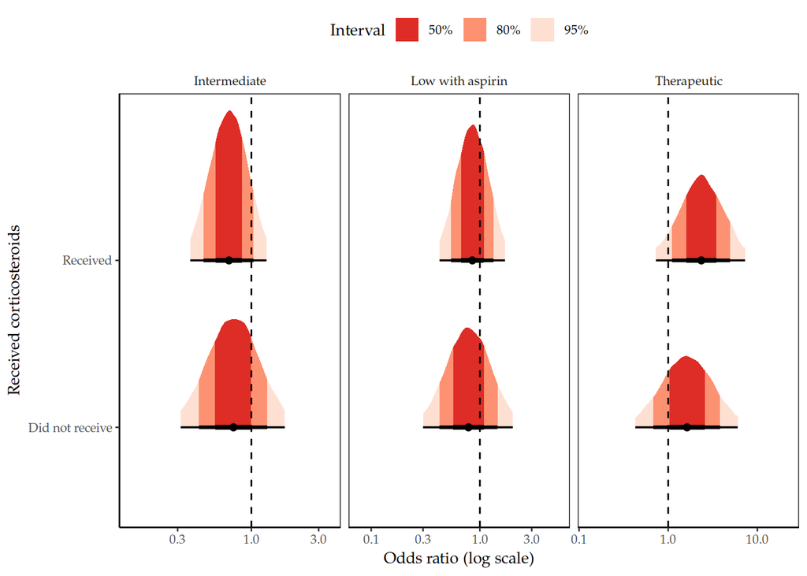

```r
p <- plot_subgroup_or(ordat, sym("Received corticosteroids"))
ggsave(file.path("outputs", "figures", "outcomes", "primary", "acs-itt-subgroup-steroids-hte.pdf"),
       p,
       height = 3, width = 6)
p
```

```r
tab <- make_subgroup_summary_table(ordat, "latex")
save_tex_table(tab, "outcomes/primary/subgroup/steroids-odds-ratios")
make_subgroup_summary_table(ordat)
```

| Received corticosteroids | Median | 95\% CrI | Mean (SD) | Pr(OR < 1) | Pr(OR > 1/1.1) |
| --- | --- | --- | --- | --- | --- |
| **Intermediate** |  |  |  |  |  |
| Did not receive | 0.75 | (0.32, 1.73) | 0.82 (0.37) | 0.75 | 0.32 |
| Received | 0.69 | (0.37, 1.28) | 0.73 (0.23) | 0.88 | 0.19 |
| **Low with aspirin** |  |  |  |  |  |
| Did not receive | 0.79 | (0.30, 2.01) | 0.88 (0.44) | 0.69 | 0.38 |
| Received | 0.85 | (0.43, 1.70) | 0.91 (0.33) | 0.67 | 0.43 |
| **Therapeutic** |  |  |  |  |  |
| Did not receive | 1.63 | (0.43, 6.02) | 2.03 (1.50) | 0.23 | 0.81 |
| Received | 2.35 | (0.73, 7.27) | 2.77 (1.73) | 0.07 | 0.94 |

```r
tab <- make_subgroup_summary_table(compdat, "latex")
save_tex_table(tab, "outcomes/primary/subgroup/steroids-odds-ratios-compare")
make_subgroup_summary_table(compdat)
```

| Received corticosteroids | Median | 95\% CrI | Mean (SD) | Pr(OR < 1) |
| --- | --- | --- | --- | --- |
| **Intermediate** |  |  |  |  |
| Did not receive | 1.00 | (1.00, 1.00) | 1.00 (0.00) | 0.00 |
| Received | 0.92 | (0.35, 2.49) | 1.05 (0.55) | 0.56 |
| **Low with aspirin** |  |  |  |  |
| Did not receive | 1.00 | (1.00, 1.00) | 1.00 (0.00) | 0.00 |
| Received | 1.09 | (0.38, 3.10) | 1.25 (0.73) | 0.44 |
| **Therapeutic** |  |  |  |  |
| Did not receive | 1.00 | (1.00, 1.00) | 1.00 (0.00) | 0.00 |
| Received | 1.44 | (0.37, 5.60) | 1.85 (1.46) | 0.30 |

### Received remdesivir

It is noted that receipt of remdesivir is a post-randomisation event, and therefore may be affected by both the assigned treatment and the patients progression making interpretation difficult.

```r
make_subgroup_remdesivir_table <- function(format = "html") {
  make_base_subgroup_table(acs_itt_dat, rec_remdesivir, format = format) %>%
  pack_rows("Did not receive remdesivir", 1, 4) %>%
  pack_rows("Received remdesivir", 5, 8)
}
tab <- make_subgroup_remdesivir_table("latex")
save_tex_table(tab, "outcomes/primary/descriptive-acs-itt-subgroup-remdesivir-descriptive")
make_subgroup_remdesivir_table()
```

| Anticoagulation intervention | Patients | Known | Primary outcome |
| --- | --- | --- | --- |
| **Did not receive remdesivir** |  |  |  |
| Low dose | 324 | 315 | 7 (2%) |
| Intermediate dose | 324 | 316 | 6 (2%) |
| Low dose with aspirin | 114 | 112 | 2 (2%) |
| Therapeutic dose | 40 | 40 | 5 (12%) |
| **Received remdesivir** |  |  |  |
| Low dose | 286 | 281 | 28 (10%) |
| Intermediate dose | 289 | 285 | 19 (7%) |
| Low dose with aspirin | 169 | 167 | 18 (11%) |
| Therapeutic dose | 10 | 10 | 2 (20%) |

Primary outcome by anti-coagulation intervention by receipt of remdesivir.

```r
res <- fit_primary_model(
  acs_itt_nona_dat,
  primary_mod,
  vars = c("CAssignment", "AAssignment", "inelgc3", "agegte60", "rec_remdesivir", "ctry", "CAssignment:rec_remdesivir"),
  beta_sd = c(2.5, rep(1, 5), 10, 2.5, 2.5, 1, 1, rep(1, 3)),
  ctr = contr.treatment,
  seed = 88071,
  iter_warmup = 500,
  iter_sampling = 2500,
  chains = 8,
  parallel_chains = min(8, parallel::detectCores()),
  adapt_delta = 0.98
)

# Derive subgroup-specific effects
labs <- c("Did not receive", "Received")
betaC <- res$drws$beta[grepl("CAssignment", names(res$drws$beta))]
res$drws$trt1 <- betaC[1:3]
res$drws$trt2 <- betaC[1:3] + betaC[4:6]
res$drws$logOR <- rbind(res$drws$trt1, res$drws$trt2)
res$drws$OR <- exp(res$drws$logOR)
rownames(res$drws$OR) <- labs
colnames(res$drws$OR) <- intervention_labels_short()$CAssignment[-(1:2)]
res$drws$compare <- sweep(res$drws$OR, 2, res$drws$OR[1, ], FUN = "/")

ordat <- expand_grid(
  Contrast = intervention_labels_short()$CAssignment[-(1:2)],
  `Received remdesivir` = labs
) %>%
  mutate(Posterior = c(res$drws$OR)) %>%
  summarise_posterior()
compdat <- expand_grid(
  Contrast = intervention_labels_short()$CAssignment[-(1:2)],
  `Received remdesivir` = labs
) %>%
  mutate(Posterior = c(res$drws$compare)) %>%
  summarise_posterior() %>%
  select(-`Pr(OR > 1/1.1)`)
```

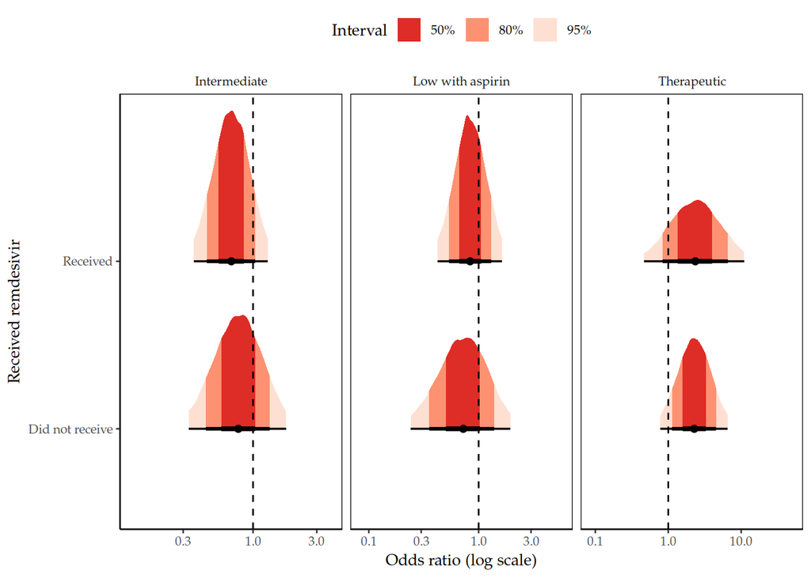

```r
p <- plot_subgroup_or(ordat, sym("Received remdesivir"))
ggsave(
  file.path("outputs", "figures", "outcomes", "primary", "acs-itt-subgroup-remdesivir-hte.pdf"),
  p, height = 3, width = 6)
p
```

```r
tab <- make_subgroup_summary_table(ordat, "latex")
save_tex_table(tab, "outcomes/primary/subgroup/remdesivir-odds-ratios")
make_subgroup_summary_table(ordat)
```

| Received remdesivir | Median | 95\% CrI | Mean (SD) | Pr(OR < 1) | Pr(OR > 1/1.1) |
| --- | --- | --- | --- | --- | --- |
| **Intermediate** |  |  |  |  |  |
| Did not receive | 0.78 | (0.33, 1.77) | 0.85 (0.37) | 0.73 | 0.36 |
| Received | 0.69 | (0.36, 1.29) | 0.72 (0.24) | 0.88 | 0.19 |
| **Low with aspirin** |  |  |  |  |  |
| Did not receive | 0.72 | (0.24, 1.94) | 0.82 (0.45) | 0.73 | 0.33 |
| Received | 0.84 | (0.42, 1.63) | 0.89 (0.31) | 0.70 | 0.40 |
| **Therapeutic** |  |  |  |  |  |
| Did not receive | 2.27 | (0.78, 6.50) | 2.62 (1.52) | 0.07 | 0.95 |
| Received | 2.35 | (0.47, 11.03) | 3.20 (2.96) | 0.15 | 0.88 |

```r
tab <- make_subgroup_summary_table(compdat, "latex")
save_tex_table(tab, "outcomes/primary/subgroup/remdesivir-odds-ratios-compare")
make_subgroup_summary_table(compdat)
```

| Received remdesivir | Median | 95\% CrI | Mean (SD) | Pr(OR < 1) |
| --- | --- | --- | --- | --- |
| **Intermediate** |  |  |  |  |
| Did not receive | 1.00 | (1.00, 1.00) | 1.00 (0.00) | 0.00 |
| Received | 0.89 | (0.34, 2.36) | 1.00 (0.53) | 0.60 |
| **Low with aspirin** |  |  |  |  |
| Did not receive | 1.00 | (1.00, 1.00) | 1.00 (0.00) | 0.00 |
| Received | 1.16 | (0.40, 3.60) | 1.38 (0.89) | 0.40 |
| **Therapeutic** |  |  |  |  |
| Did not receive | 1.00 | (1.00, 1.00) | 1.00 (0.00) | 0.00 |
| Received | 1.03 | (0.23, 4.63) | 1.37 (1.25) | 0.48 |

### Receipt of other agent intended to be an antiviral agent against SARS-CoV-2

```r
make_subgroup_antiviral_table <- function(format = "html") {
  make_base_subgroup_table(acs_itt_dat, rec_antiviral, format = format) %>%
  pack_rows("Did not receive other antiviral", 1, 4) %>%
  pack_rows("Received other antiviral", 5, 8)
}
tab <- make_subgroup_antiviral_table("latex")
save_tex_table(tab, "outcomes/primary/descriptive-acs-itt-subgroup-antiviral-descriptive")
make_subgroup_antiviral_table()
```

| Anticoagulation intervention | Patients | Known | Primary outcome |
| --- | --- | --- | --- |
| **Did not receive other antiviral** |  |  |  |
| Low dose | 337 | 324 | 27 (8%) |
| Intermediate dose | 340 | 331 | 23 (7%) |
| Low dose with aspirin | 169 | 165 | 13 (8%) |
| Therapeutic dose | 48 | 48 | 7 (15%) |
| **Received other antiviral** |  |  |  |
| Low dose | 273 | 272 | 8 (3%) |
| Intermediate dose | 273 | 270 | 2 (1%) |
| Low dose with aspirin | 114 | 114 | 7 (6%) |
| Therapeutic dose | 2 | 2 | 0 (0%) |

```r
res <- fit_primary_model(
  acs_itt_nona_dat,
  primary_mod,
  vars = c("CAssignment", "AAssignment", "inelgc3", "agegte60", "rec_antiviral", "ctry", "CAssignment:rec_antiviral"),
  beta_sd = c(2.5, rep(1, 5), 10, 2.5, 2.5, 1, 1, rep(1, 3)),
  ctr = contr.treatment,
  seed = 44106,
  iter_warmup = 500,
  iter_sampling = 2500,
  chains = 4,
  parallel_chains = 4,
  adapt_delta = 0.98
)

# Derive subgroup-specific effects
labs <- c("No", "Yes")
betaC <- res$drws$beta[grepl("CAssignment", names(res$drws$beta))]
res$drws$trt1 <- betaC[1:3]
res$drws$trt2 <- betaC[1:3] + betaC[4:6]
res$drws$logOR <- rbind(res$drws$trt1, res$drws$trt2)
res$drws$OR <- exp(res$drws$logOR)
rownames(res$drws$OR) <- labs
colnames(res$drws$OR) <- intervention_labels_short()$CAssignment[-(1:2)]
res$drws$compare <- sweep(res$drws$OR, 2, res$drws$OR[1, ], FUN = "/")

ordat <- expand_grid(
  Contrast = intervention_labels_short()$CAssignment[-(1:2)],
  `Received other antiviral` = labs
) %>%
  mutate(Posterior = c(res$drws$OR)) %>%
  summarise_posterior()
compdat <- expand_grid(
  Contrast = intervention_labels_short()$CAssignment[-(1:2)],
  `Received other antiviral` = labs
) %>%
  mutate(Posterior = c(res$drws$compare)) %>%
  summarise_posterior() %>%
  select(-`Pr(OR > 1/1.1)`)
```

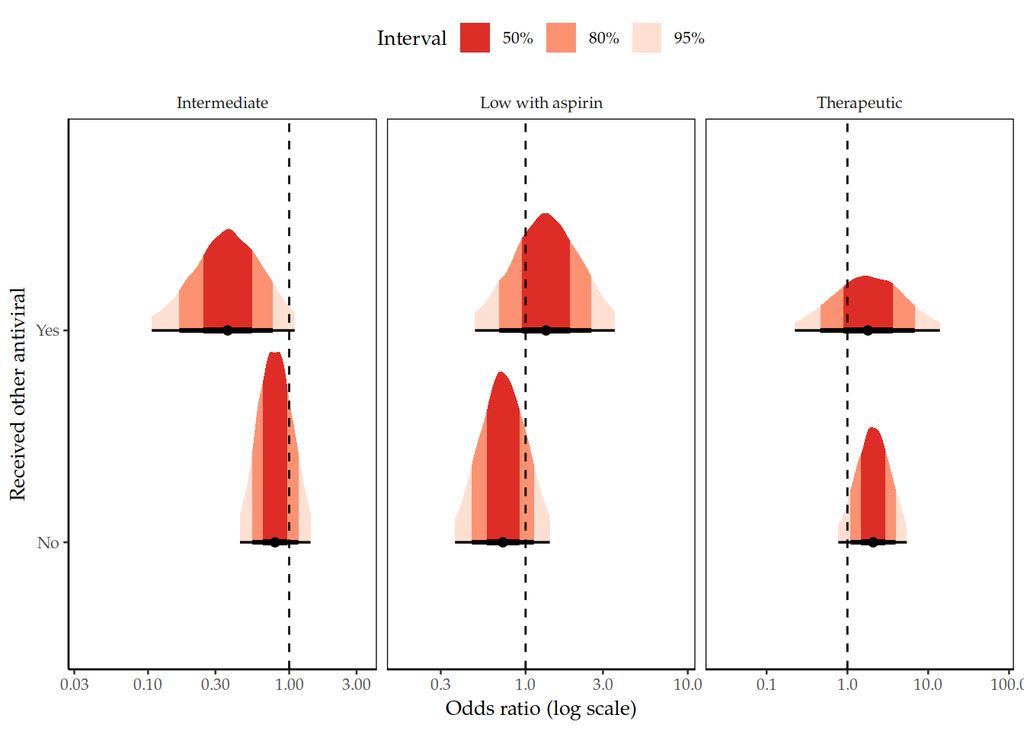

```r
p <- plot_subgroup_or(ordat, sym("Received other antiviral"))
ggsave(
  file.path("outputs", "figures", "outcomes", "primary", "acs-itt-subgroup-antiviral-hte.pdf"),
  p, height = 3, width = 6)
p
```

```r
tab <- make_subgroup_summary_table(ordat, "latex")
save_tex_table(tab, "outcomes/primary/subgroup/antiviral-odds-ratios")
make_subgroup_summary_table(ordat)
```

| Received other antiviral | Median | 95\% CrI | Mean (SD) | Pr(OR < 1) | Pr(OR > 1/1.1) |
| --- | --- | --- | --- | --- | --- |
| **Intermediate** |  |  |  |  |  |
| No | 0.79 | (0.45, 1.42) | 0.83 (0.25) | 0.78 | 0.33 |
| Yes | 0.37 | (0.11, 1.09) | 0.43 (0.26) | 0.96 | 0.05 |
| **Low with aspirin** |  |  |  |  |  |
| No | 0.72 | (0.37, 1.41) | 0.77 (0.27) | 0.82 | 0.26 |
| Yes | 1.34 | (0.49, 3.55) | 1.52 (0.81) | 0.28 | 0.78 |
| **Therapeutic** |  |  |  |  |  |
| No | 2.09 | (0.77, 5.43) | 2.36 (1.27) | 0.07 | 0.95 |
| Yes | 1.80 | (0.22, 13.95) | 3.10 (4.25) | 0.29 | 0.74 |

```r
tab <- make_subgroup_summary_table(compdat, "latex")
save_tex_table(tab, "outcomes/primary/subgroup/antiviral-odds-ratios-compare")
make_subgroup_summary_table(compdat)
```

| Received other antiviral | Median | 95\% CrI | Mean (SD) | Pr(OR < 1) |
| --- | --- | --- | --- | --- |
| **Intermediate** |  |  |  |  |
| No | 1.00 | (1.00, 1.00) | 1.00 (0.00) | 0.00 |
| Yes | 0.46 | (0.13, 1.48) | 0.55 (0.36) | 0.90 |
| **Low with aspirin** |  |  |  |  |
| No | 1.00 | (1.00, 1.00) | 1.00 (0.00) | 0.00 |
| Yes | 1.86 | (0.61, 5.48) | 2.15 (1.30) | 0.14 |
| **Therapeutic** |  |  |  |  |
| No | 1.00 | (1.00, 1.00) | 1.00 (0.00) | 0.00 |
| Yes | 0.87 | (0.13, 5.31) | 1.33 (1.55) | 0.56 |

### D-dimer

```r
make_subgroup_ddimer_table <- function(format = "html") {
  make_base_subgroup_table(acs_itt_dat, ddimer_oor, format = format) %>%
  pack_rows("D-Dimer in range", 1, 4) %>%
  pack_rows("D-Dimer out of range", 5, 8) %>%
  pack_rows("D-Dimer unknown", 9, 12)
}
tab <- make_subgroup_ddimer_table("latex")
save_tex_table(tab, "outcomes/primary/descriptive-acs-itt-subgroup-ddimer-descriptive")
make_subgroup_ddimer_table()
```

| Anticoagulation intervention | Patients | Known | Primary outcome |
| --- | --- | --- | --- |
| **D-Dimer in range** |  |  |  |
| Low dose | 311 | 307 | 15 (5%) |
| Intermediate dose | 336 | 332 | 15 (5%) |
| Low dose with aspirin | 184 | 181 | 13 (7%) |
| Therapeutic dose | 7 | 7 | 0 (0%) |
| **D-Dimer out of range** |  |  |  |
| Low dose | 182 | 179 | 10 (6%) |
| Intermediate dose | 177 | 174 | 3 (2%) |
| Low dose with aspirin | 63 | 62 | 7 (11%) |
| Therapeutic dose | 10 | 10 | 1 (10%) |
| **D-Dimer unknown** |  |  |  |
| Low dose | 117 | 110 | 10 (9%) |
| Intermediate dose | 100 | 95 | 7 (7%) |
| Low dose with aspirin | 36 | 36 | 0 (0%) |
| Therapeutic dose | 33 | 33 | 6 (18%) |

Primary outcome by anti-coagulation intervention by D-dimer out of range.

```r
res <- fit_primary_model(
  acs_itt_nona_dat,
  primary_mod,
  vars = c("CAssignment", "AAssignment", "inelgc3", "agegte60", "ddimer_oor", "ctry", "CAssignment:ddimer_oor"),
  beta_sd = c(2.5, rep(1, 5), 10, 2.5, 2.5, 2.5, 1, 1, rep(1, 6)),
  ctr = contr.treatment,
  seed = 5438,
  iter_warmup = 500,
  iter_sampling = 2500,
  chains = 8,
  parallel_chains = min(8, parallel::detectCores()),
  adapt_delta = 0.98
)

# Derive subgroup-specific effects
labs <- c("No", "Yes", "Unknown")
betaC <- res$drws$beta[grepl("CAssignment", names(res$drws$beta))]
res$drws$trt1 <- betaC[1:3]
res$drws$trt2 <- betaC[1:3] + betaC[4:6]
res$drws$trt3 <- betaC[1:3] + betaC[7:9]
res$drws$logOR <- rbind(res$drws$trt1, res$drws$trt2, res$drws$trt3)
res$drws$OR <- exp(res$drws$logOR)
rownames(res$drws$OR) <- labs
colnames(res$drws$OR) <- intervention_labels_short()$CAssignment[-(1:2)]
res$drws$compare <- sweep(res$drws$OR, 2, res$drws$OR[1, ], FUN = "/")

ordat <- expand_grid(
  Contrast = intervention_labels_short()$CAssignment[-(1:2)],
  `D-dimer out of range` = labs
) %>%
  mutate(Posterior = c(res$drws$OR)) %>%
  summarise_posterior()
compdat <- expand_grid(
  Contrast = intervention_labels_short()$CAssignment[-(1:2)],
  `D-dimer out of range` = labs
) %>%
  mutate(Posterior = c(res$drws$compare)) %>%
  summarise_posterior() %>%
  select(-`Pr(OR > 1/1.1)`)
```

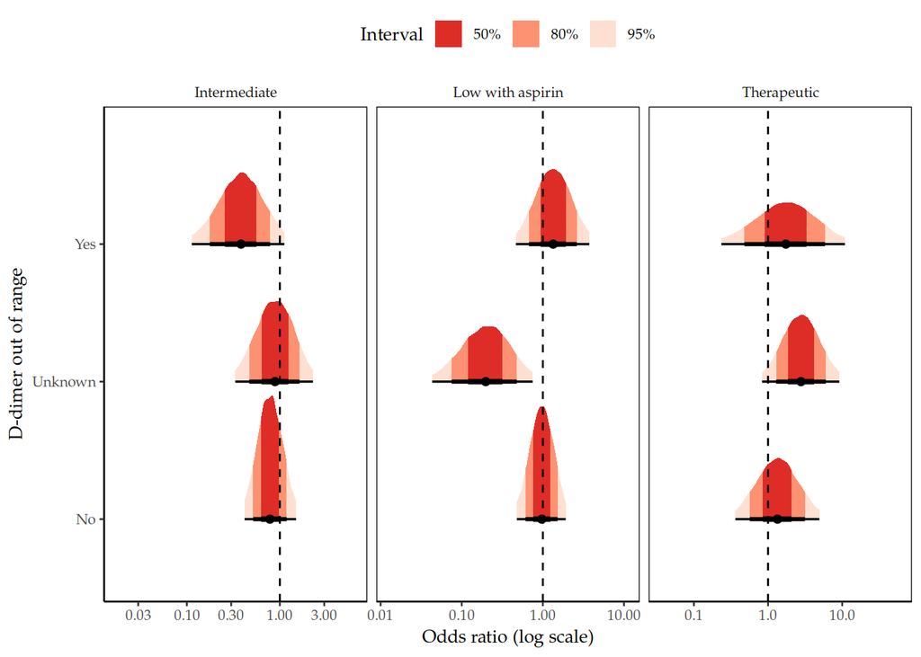

```r
p <- plot_subgroup_or(ordat, sym("D-dimer out of range"))
ggsave(
  file.path("outputs", "figures", "outcomes", "primary", "acs-itt-subgroup-ddimer-hte.pdf"),
  p, height = 3, width = 6)
p
```

```r
tab <- make_subgroup_summary_table(ordat, "latex")
save_tex_table(tab, "outcomes/primary/subgroup/ddimer-odds-ratios")
make_subgroup_summary_table(ordat)
```

| D-dimer out of range | Median | 95\% CrI | Mean (SD) | Pr(OR < 1) | Pr(OR > 1/1.1) |
| --- | --- | --- | --- | --- | --- |
| **Intermediate** |  |  |  |  |  |
| No | 0.78 | (0.42, 1.49) | 0.83 (0.28) | 0.77 | 0.32 |
| Yes | 0.38 | (0.11, 1.12) | 0.44 (0.27) | 0.96 | 0.06 |
| Unknown | 0.89 | (0.33, 2.27) | 0.99 (0.51) | 0.60 | 0.48 |
| **Low with aspirin** |  |  |  |  |  |
| No | 0.97 | (0.48, 1.91) | 1.03 (0.37) | 0.53 | 0.57 |
| Yes | 1.34 | (0.47, 3.74) | 1.54 (0.88) | 0.29 | 0.77 |
| Unknown | 0.20 | (0.04, 0.75) | 0.25 (0.19) | 0.99 | 0.01 |
| **Therapeutic** |  |  |  |  |  |
| No | 1.34 | (0.36, 4.92) | 1.66 (1.22) | 0.33 | 0.72 |
| Yes | 1.74 | (0.23, 10.90) | 2.68 (3.04) | 0.29 | 0.75 |
| Unknown | 2.78 | (0.83, 9.14) | 3.34 (2.23) | 0.05 | 0.97 |

```r
tab <- make_subgroup_summary_table(compdat, "latex")
save_tex_table(tab, "outcomes/primary/subgroup/ddimer-odds-ratios-compare")
make_subgroup_summary_table(compdat)
```

| D-dimer out of range | Median | 95\% CrI | Mean (SD) | Pr(OR < 1) |
| --- | --- | --- | --- | --- |
| **Intermediate** |  |  |  |  |
| No | 1.00 | (1.00, 1.00) | 1.00 (0.00) | 0.00 |
| Yes | 0.48 | (0.14, 1.52) | 0.58 (0.37) | 0.89 |
| Unknown | 1.12 | (0.38, 3.17) | 1.30 (0.74) | 0.41 |
| **Low with aspirin** |  |  |  |  |
| No | 1.00 | (1.00, 1.00) | 1.00 (0.00) | 0.00 |
| Yes | 1.38 | (0.45, 4.13) | 1.62 (0.98) | 0.28 |
| Unknown | 0.20 | (0.05, 0.78) | 0.26 (0.20) | 0.99 |
| **Therapeutic** |  |  |  |  |
| No | 1.00 | (1.00, 1.00) | 1.00 (0.00) | 0.00 |
| Yes | 1.29 | (0.23, 6.64) | 1.82 (1.85) | 0.39 |
| Unknown | 2.09 | (0.50, 8.57) | 2.70 (2.22) | 0.16 |

### Weight

Due to small numbers and zero events this subgroup analysis was not undertaken.

```r
make_subgroup_weight_table <- function(format = "html") {
  make_base_subgroup_table(acs_itt_dat, weightgt120, format = format) %>%
    pack_rows("Weight $\\leq$ 120 kg", 1, 4) %>%
    pack_rows("Weight > 120 kg", 5, 8)
}
tab <- make_subgroup_weight_table("latex")
save_tex_table(tab, "outcomes/primary/descriptive-acs-itt-subgroup-weight-descriptive")
make_subgroup_weight_table()
```

| Anticoagulation intervention | Patients | Known | Primary outcome |
| --- | --- | --- | --- |
| **Weight $\leq$ 120 kg** |  |  |  |
| Low dose | 599 | 587 | 35 (6%) |
| Intermediate dose | 605 | 594 | 25 (4%) |
| Low dose with aspirin | 282 | 278 | 20 (7%) |
| Therapeutic dose | 49 | 49 | 7 (14%) |
| **Weight > 120 kg** |  |  |  |
| Low dose | 11 | 9 | 0 (0%) |
| Intermediate dose | 8 | 7 | 0 (0%) |
| Low dose with aspirin | 1 | 1 | 0 (0%) |
| Therapeutic dose | 1 | 1 | 0 (0%) |

### Aspirin

```r
make_subgroup_aspirin_table <- function(format = "html") {
  make_base_subgroup_table(acs_itt_dat, aspirin, format = format) %>%
    pack_rows("Patient not taking aspirin", 1, 4) %>%
    pack_rows("Patient taking aspirin", 5, 8)
}
tab <- make_subgroup_aspirin_table("latex")
save_tex_table(tab, "outcomes/primary/descriptive-acs-itt-subgroup-aspirin-descriptive")
make_subgroup_aspirin_table()
```

| Anticoagulation intervention | Patients | Known | Primary outcome |
| --- | --- | --- | --- |
| **Patient not taking aspirin** |  |  |  |
| Low dose | 590 | 576 | 30 (5%) |
| Intermediate dose | 588 | 576 | 23 (4%) |
| Low dose with aspirin | 281 | 277 | 19 (7%) |
| Therapeutic dose | 47 | 47 | 7 (15%) |
| **Patient taking aspirin** |  |  |  |
| Low dose | 20 | 20 | 5 (25%) |
| Intermediate dose | 25 | 25 | 2 (8%) |
| Low dose with aspirin | 2 | 2 | 1 (50%) |
| Therapeutic dose | 3 | 3 | 0 (0%) |

Primary outcome by anti-coagulation intervention by aspirin use

```r
res <- fit_primary_model(
  acs_itt_nona_dat,
  primary_mod,
  vars = c("CAssignment", "AAssignment", "inelgc3", "agegte60", "aspirin", "ctry", "CAssignment:aspirin"),
  beta_sd = c(2.5, rep(1, 5), 10, 2.5, 2.5, 1, 1, rep(1, 3)),
  ctr = contr.treatment,
  seed = 5438,
  iter_warmup = 500,
  iter_sampling = 2500,
  chains = 8,
  parallel_chains = min(8, parallel::detectCores()),
  adapt_delta = 0.98
)

# Derive subgroup-specific effects
labs <- c("No", "Yes")
betaC <- res$drws$beta[grepl("CAssignment", names(res$drws$beta))]
res$drws$trt1 <- betaC[1:3]
res$drws$trt2 <- betaC[1:3] + betaC[4:6]
res$drws$logOR <- rbind(res$drws$trt1, res$drws$trt2)
res$drws$OR <- exp(res$drws$logOR)
rownames(res$drws$OR) <- labs
colnames(res$drws$OR) <- intervention_labels_short()$CAssignment[-(1:2)]
res$drws$compare <- sweep(res$drws$OR, 2, res$drws$OR[1, ], FUN = "/")

ordat <- expand_grid(
  Contrast = intervention_labels_short()$CAssignment[-(1:2)],
  `Patient taking aspirin` = labs
) %>%
  mutate(Posterior = c(res$drws$OR)) %>%
  summarise_posterior()
compdat <- expand_grid(
  Contrast = intervention_labels_short()$CAssignment[-(1:2)],
  `Patient taking aspirin` = labs
) %>%
  mutate(Posterior = c(res$drws$compare)) %>%
  summarise_posterior() %>%
  select(-`Pr(OR > 1/1.1)`)
```

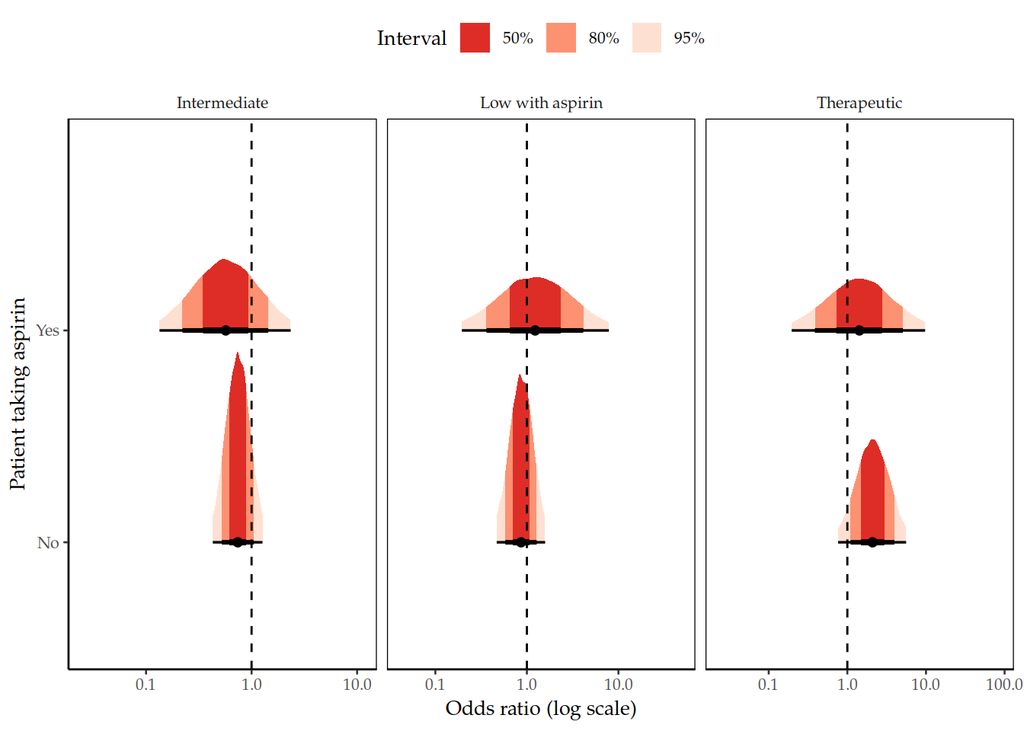

```r
p <- plot_subgroup_or(ordat, sym("Patient taking aspirin"))
ggsave(file.path("outputs", "figures", "outcomes", "primary", "acs-itt-subgroup-aspirin-hte.pdf"),
       p, height = 3, width = 6)
p
```

```r
tab <- make_subgroup_summary_table(ordat, "latex")
save_tex_table(tab, "outcomes/primary/subgroup/aspirin-odds-ratios")
make_subgroup_summary_table(ordat)
```

| Patient taking aspirin | Median | 95\% CrI | Mean (SD) | Pr(OR < 1) | Pr(OR > 1/1.1) |
| --- | --- | --- | --- | --- | --- |
| **Intermediate** |  |  |  |  |  |
| No | 0.74 | (0.43, 1.27) | 0.77 (0.21) | 0.86 | 0.22 |
| Yes | 0.57 | (0.13, 2.35) | 0.74 (0.60) | 0.78 | 0.26 |
| **Low with aspirin** |  |  |  |  |  |
| No | 0.86 | (0.47, 1.58) | 0.91 (0.29) | 0.68 | 0.44 |
| Yes | 1.23 | (0.19, 7.87) | 1.92 (2.26) | 0.42 | 0.62 |
| **Therapeutic** |  |  |  |  |  |
| No | 2.09 | (0.76, 5.59) | 2.37 (1.27) | 0.07 | 0.95 |
| Yes | 1.42 | (0.20, 9.76) | 2.32 (2.99) | 0.36 | 0.67 |

```r
tab <- make_subgroup_summary_table(compdat, "latex")
save_tex_table(tab, "outcomes/primary/subgroup/aspirin-odds-ratios-compare")
make_subgroup_summary_table(compdat)
```

| Patient taking aspirin | Median | 95\% CrI | Mean (SD) | Pr(OR < 1) |
| --- | --- | --- | --- | --- |
| **Intermediate** |  |  |  |  |
| No | 1.00 | (1.00, 1.00) | 1.00 (0.00) | 0.00 |
| Yes | 0.77 | (0.18, 3.10) | 0.99 (0.79) | 0.64 |
| **Low with aspirin** |  |  |  |  |
| No | 1.00 | (1.00, 1.00) | 1.00 (0.00) | 0.00 |
| Yes | 1.42 | (0.24, 8.47) | 2.14 (2.35) | 0.35 |
| **Therapeutic** |  |  |  |  |
| No | 1.00 | (1.00, 1.00) | 1.00 (0.00) | 0.00 |
| Yes | 0.68 | (0.11, 4.00) | 1.02 (1.14) | 0.67 |

### Vaccination Status (post-hoc)

```r
make_subgroup_vax_table <- function(format = "html") {
  make_base_subgroup_table(acs_itt_dat, vax, format = format)  %>%
  pack_rows("Not vaccinated", 1, 4) %>%
  pack_rows("Vaccinated", 5, 8)  %>%
  pack_rows("Unknown", 9, 12)
}
tab <- make_subgroup_vax_table("latex")
save_tex_table(tab, "outcomes/primary/descriptive-acs-itt-subgroup-vax-descriptive")
make_subgroup_vax_table()
```

| Anticoagulation intervention | Patients | Known | Primary outcome |
| --- | --- | --- | --- |
| **Not vaccinated** |  |  |  |
| Low dose | 387 | 378 | 24 (6%) |
| Intermediate dose | 371 | 362 | 15 (4%) |
| Low dose with aspirin | 212 | 208 | 14 (7%) |
| Therapeutic dose | 23 | 23 | 4 (17%) |
| **Vaccinated** |  |  |  |
| Low dose | 191 | 186 | 3 (2%) |
| Intermediate dose | 220 | 217 | 5 (2%) |
| Low dose with aspirin | 42 | 42 | 1 (2%) |
| Therapeutic dose | 27 | 27 | 3 (11%) |
| **Unknown** |  |  |  |
| Low dose | 32 | 32 | 8 (25%) |
| Intermediate dose | 22 | 22 | 5 (23%) |
| Low dose with aspirin | 29 | 29 | 5 (17%) |
| Therapeutic dose | 0 | 0 | - (-%) |

Primary outcome by anti-coagulation intervention by vaccination status

```r
res <- fit_primary_model(
  acs_itt_nona_dat,
  primary_mod,
  vars = c("CAssignment", "AAssignment", "inelgc3", "agegte60", "ctry", "vaxfac", "CAssignment:vaxfac"),
  beta_sd = c(2.5, rep(1, 5), 10, 2.5, 1, 1, 2.5, 2.5, rep(1, 6)),
  ctr = contr.treatment,
  seed = 44106,
  iter_warmup = 500,
  iter_sampling = 500,
  chains = 4,
  parallel_chains = 4,
  adapt_delta = 0.98
)

# Derive subgroup-specific effects
labs <- c("Not vaccinated", "Vaccinated", "Unknown")
betaC <- res$drws$beta[grepl("CAssignment", names(res$drws$beta))]
res$drws$trt1 <- betaC[1:3]
res$drws$trt2 <- betaC[1:3] + betaC[4:6]
res$drws$trt3 <- betaC[1:3] + betaC[7:9]
res$drws$logOR <- rbind(res$drws$trt1, res$drws$trt2, res$drws$trt3)
res$drws$OR <- exp(res$drws$logOR)
rownames(res$drws$OR) <- labs
colnames(res$drws$OR) <- intervention_labels_short()$CAssignment[-(1:2)]
res$drws$compare <- sweep(res$drws$OR, 2, res$drws$OR[1, ], FUN = "/")

# Summarise subgroup effects
ordat <- expand_grid(
  Contrast = intervention_labels_short()$CAssignment[-(1:2)],
  `Vaccination status` = fct_inorder(labs),
) %>%
  mutate(Posterior = c(res$drws$OR)) %>%
  summarise_posterior()
# Summarise comparison of effects (reference is India)
compdat <- expand_grid(
  Contrast = intervention_labels_short()$CAssignment[-(1:2)],
  `Vaccination status` = fct_inorder(labs)
) %>%
  mutate(Posterior = c(res$drws$compare)) %>%
  summarise_posterior() %>%
  select(-`Pr(OR > 1/1.1)`)
```

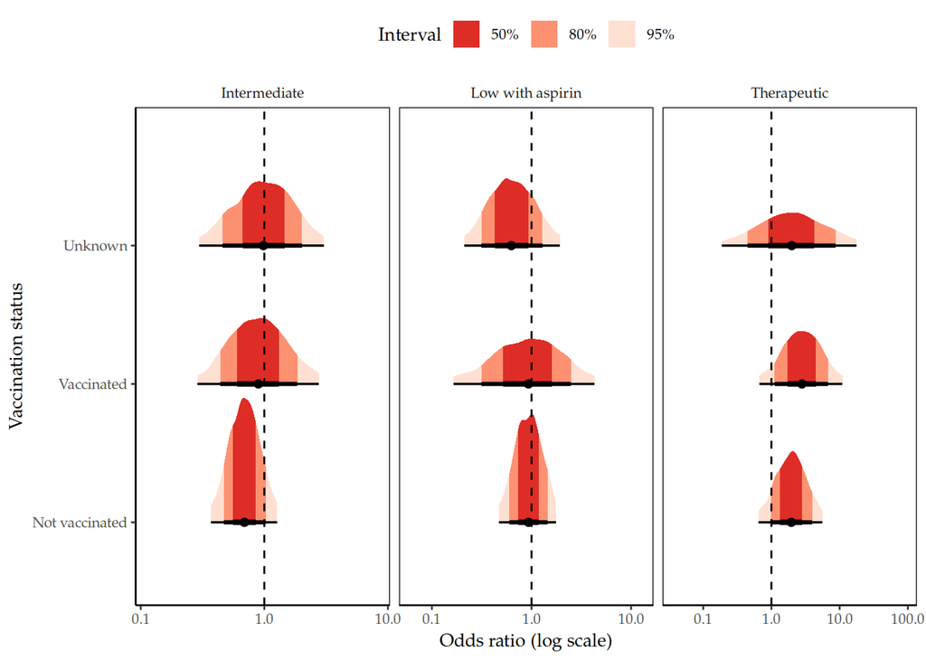

```r
p <- plot_subgroup_or(ordat, sym("Vaccination status"))
ggsave(
  file.path("outputs", "figures", "outcomes", "primary", "acs-itt-subgroup-vax-hte.pdf"),
  p, height = 3, width = 6)
p
```

```r
tab <- make_subgroup_summary_table(ordat, "latex")
save_tex_table(tab, "outcomes/primary/subgroup/vax-odds-ratios")
make_subgroup_summary_table(ordat)
```

| Vaccination status | Median | 95\% CrI | Mean (SD) | Pr(OR < 1) | Pr(OR > 1/1.1) |
| --- | --- | --- | --- | --- | --- |
| **Intermediate** |  |  |  |  |  |
| Not vaccinated | 0.69 | (0.37, 1.27) | 0.73 (0.23) | 0.89 | 0.19 |
| Vaccinated | 0.89 | (0.29, 2.76) | 1.05 (0.67) | 0.58 | 0.49 |
| Unknown | 0.98 | (0.30, 3.04) | 1.16 (0.72) | 0.51 | 0.56 |
| **Low with aspirin** |  |  |  |  |  |
| Not vaccinated | 0.93 | (0.47, 1.76) | 0.99 (0.34) | 0.58 | 0.53 |
| Vaccinated | 0.93 | (0.16, 4.28) | 1.25 (1.14) | 0.54 | 0.52 |
| Unknown | 0.63 | (0.21, 1.92) | 0.74 (0.45) | 0.79 | 0.26 |
| **Therapeutic** |  |  |  |  |  |
| Not vaccinated | 1.96 | (0.64, 5.57) | 2.24 (1.29) | 0.11 | 0.91 |
| Vaccinated | 2.80 | (0.67, 10.92) | 3.54 (2.81) | 0.08 | 0.94 |
| Unknown | 1.98 | (0.19, 17.69) | 3.78 (5.80) | 0.28 | 0.75 |

```r
tab <- make_subgroup_summary_table(compdat, "latex")
save_tex_table(tab, "outcomes/primary/subgroup/vax-odds-ratios-compare")
make_subgroup_summary_table(compdat)
```

| Vaccination status | Median | 95\% CrI | Mean (SD) | Pr(OR < 1) |
| --- | --- | --- | --- | --- |
| **Intermediate** |  |  |  |  |
| Not vaccinated | 1.00 | (1.00, 1.00) | 1.00 (0.00) | 0.00 |
| Vaccinated | 1.30 | (0.41, 4.18) | 1.54 (0.99) | 0.34 |
| Unknown | 1.41 | (0.41, 4.84) | 1.71 (1.13) | 0.29 |
| **Low with aspirin** |  |  |  |  |
| Not vaccinated | 1.00 | (1.00, 1.00) | 1.00 (0.00) | 0.00 |
| Vaccinated | 1.02 | (0.19, 4.12) | 1.31 (1.12) | 0.49 |
| Unknown | 0.68 | (0.22, 2.12) | 0.81 (0.50) | 0.73 |
| **Therapeutic** |  |  |  |  |
| Not vaccinated | 1.00 | (1.00, 1.00) | 1.00 (0.00) | 0.00 |
| Vaccinated | 1.44 | (0.34, 6.00) | 1.88 (1.86) | 0.31 |
| Unknown | 1.00 | (0.14, 7.24) | 1.64 (1.90) | 0.50 |